# APM1110-FA6_Paglinawan_ZeusAlexis

Zeus Paglinawan

2026-09-19

## I. Geometric Distribution

**Provide an R code for the geometric distribution. The geometric distribution is a probability distribution that models the number of trials required to achieve the first success in a sequence of Bernoulli trials, where each trial has a constant probability of success.**

**1. Set the probability of success: p ← 0.2**

**2. Generate 1000 random variables from the geometric distribution.**

**3. Calculate basic statistics:**

**mean_x <- mean(x)**

**var_x <- var(x)**

**sd_x <- sd(x)**

**4. Print the results in item 3 with the following output format (string):**

**Number of trials required to achieve first success:**

**Mean (in 2 decimal places):**

**Variance (in 2 decimal places):**

**Standard deviation (in 2 decimal places):**

**5. Plot the histogram of the results.**

```r
# 1 Probability of success
p <- 0.2

# 2 Generate 1000 random variables
x <- rgeom(1000, p) + 1

# 3 Calculate basic statistics
mean_x <- mean(x)
var_x <- var(x)
sd_x <- sd(x)

# 4 Print results
cat("Number of trials required to achieve first success: \n")
```

```
Number of trials required to achieve first success:
```

```r
for (i in seq(1, length(x), by = 20)) {
  cat(paste(x[i:min(i + 19, length(x))], collapse = " "))
  cat("\n")
}
```

[output not shown]

[output cut: 35 more lines]

```r
cat("Mean (in 2 decimal places):", sprintf("%.2f", mean_x), "\n")
```

```
Mean (in 2 decimal places): 5.01
```

```r
cat("Variance (in 2 decimal places):", sprintf("%.2f", var_x), "\n")
```

```
Variance (in 2 decimal places): 18.54
```

```r
cat("Standard deviation (in 2 decimal places):", sprintf("%.2f", sd_x), "\n")
```

```
Standard deviation (in 2 decimal places): 4.31
```

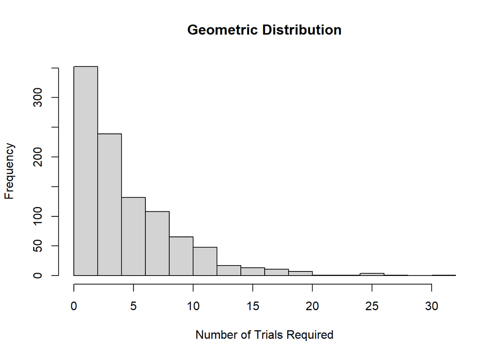

```r
# 5 Histogram
hist(x,
     main = "Geometric Distribution",
     xlab = "Number of Trials Required",
     ylab = "Frequency")
```

## II. Hypergeometric Distribution

**Consider a plant manufacturing IC chips of which 10% are expected to be defective. The chips are packed in boxes for export. Before transportation, a sample is drawn from each box. Estimate the probability that the sample contains more than 10% defectives, when:**

**1. A sample of 10 is selected from a box of 40;**

**2. A sample of 10 is selected from a box of 5000.**

```r
# Box of 40
box1 <- 40
defective1 <- 4
sample1 <- 10

# More than 10% of 10 means at least 2 defective chips
P1 <- 1 - phyper(1, defective1, box1 - defective1, sample1)

cat("Probability for a sample of 10 from a box of 40:",
    sprintf("%.4f", P1), "\n")
```

```
Probability for a sample of 10 from a box of 40: 0.2559
```

```r
# Box of 5000
box2 <- 5000
defective2 <- 500
sample2 <- 10

# More than 10% of 10 means at least 2 defective chips
P2 <- 1 - phyper(1, defective2, box2 - defective2, sample2)

cat("Probability for a sample of 10 from a box of 5000:",
    sprintf("%.4f", P2), "\n")
```

```
Probability for a sample of 10 from a box of 5000: 0.2639
```

### Interpretation

For a box of 40 chips, 10% defective means there are 4 defective chips. Since the sample size is 10, more than 10% defective means having at least 2 defective chips. The probability of this occurring is 0.2559, or 25.59%.

For a box of 5000 chips, 10% defective means there are 500 defective chips. Again, more than 10% defective in a sample of 10 means at least 2 defective chips. The probability of this occurring is 0.2639, or 26.39%.